# Data EDA

## Highlight

First, let's import our basic libraries and set the option to display all columns in the data.

```python
#common imports
import pandas as pd
import numpy as np

#Additional imports/optional
from pandas import Series, DataFrame

#This suppress SettingWithCopyWarning
pd.options.mode.chained_assignment = None  # default='warn'

# set display columns - Do not change or CodeGrade may not function correctly
pd.set_option('display.max_columns', None)
```

**Exercise:** Import the data from the `fandango.csv` file and save as a DataFrame called `fandango`. Look at the first five rows.

```python
# load data from the fandango.csv file

fandango = pd.read_csv('fandango.csv')
fandango#.head(5)
```

|  | FILM | RottenTomatoes | RottenTomatoes_User | Metacritic | Metacritic_User | IMDB | Fandango_Stars | Fandango_Ratingvalue | RT_norm | RT_user_norm | Metacritic_norm | Metacritic_user_nom | IMDB_norm | RT_norm_round | RT_user_norm_round | Metacritic_norm_round | Metacritic_user_norm_round | IMDB_norm_round | Metacritic_user_vote_count | IMDB_user_vote_count | Fandango_votes | Fandango_Difference |
| --- | --- | --- | --- | --- | --- | --- | --- | --- | --- | --- | --- | --- | --- | --- | --- | --- | --- | --- | --- | --- | --- | --- |
| 0 | Avengers: Age of Ultron (2015) | 74 | 86 | 66 | 7.1 | 7.8 | 5.0 | 4.5 | 3.70 | 4.30 | 3.30 | 3.55 | 3.90 | 3.5 | 4.5 | 3.5 | 3.5 | 4.0 | 1330 | 271107 | 14846 | 0.5 |
| 1 | Cinderella (2015) | 85 | 80 | 67 | 7.5 | 7.1 | 5.0 | 4.5 | 4.25 | 4.00 | 3.35 | 3.75 | 3.55 | 4.5 | 4.0 | 3.5 | 4.0 | 3.5 | 249 | 65709 | 12640 | 0.5 |
| 2 | Ant-Man (2015) | 80 | 90 | 64 | 8.1 | 7.8 | 5.0 | 4.5 | 4.00 | 4.50 | 3.20 | 4.05 | 3.90 | 4.0 | 4.5 | 3.0 | 4.0 | 4.0 | 627 | 103660 | 12055 | 0.5 |
| 3 | Do You Believe? (2015) | 18 | 84 | 22 | 4.7 | 5.4 | 5.0 | 4.5 | 0.90 | 4.20 | 1.10 | 2.35 | 2.70 | 1.0 | 4.0 | 1.0 | 2.5 | 2.5 | 31 | 3136 | 1793 | 0.5 |
| 4 | Hot Tub Time Machine 2 (2015) | 14 | 28 | 29 | 3.4 | 5.1 | 3.5 | 3.0 | 0.70 | 1.40 | 1.45 | 1.70 | 2.55 | 0.5 | 1.5 | 1.5 | 1.5 | 2.5 | 88 | 19560 | 1021 | 0.5 |
| ... | ... | ... | ... | ... | ... | ... | ... | ... | ... | ... | ... | ... | ... | ... | ... | ... | ... | ... | ... | ... | ... | ... |
| 141 | Mr. Holmes (2015) | 87 | 78 | 67 | 7.9 | 7.4 | 4.0 | 4.0 | 4.35 | 3.90 | 3.35 | 3.95 | 3.70 | 4.5 | 4.0 | 3.5 | 4.0 | 3.5 | 33 | 7367 | 1348 | 0.0 |
| 142 | '71 (2015) | 97 | 82 | 83 | 7.5 | 7.2 | 3.5 | 3.5 | 4.85 | 4.10 | 4.15 | 3.75 | 3.60 | 5.0 | 4.0 | 4.0 | 4.0 | 3.5 | 60 | 24116 | 192 | 0.0 |
| 143 | Two Days, One Night (2014) | 97 | 78 | 89 | 8.8 | 7.4 | 3.5 | 3.5 | 4.85 | 3.90 | 4.45 | 4.40 | 3.70 | 5.0 | 4.0 | 4.5 | 4.5 | 3.5 | 123 | 24345 | 118 | 0.0 |
| 144 | Gett: The Trial of Viviane Amsalem (2015) | 100 | 81 | 90 | 7.3 | 7.8 | 3.5 | 3.5 | 5.00 | 4.05 | 4.50 | 3.65 | 3.90 | 5.0 | 4.0 | 4.5 | 3.5 | 4.0 | 19 | 1955 | 59 | 0.0 |
| 145 | Kumiko, The Treasure Hunter (2015) | 87 | 63 | 68 | 6.4 | 6.7 | 3.5 | 3.5 | 4.35 | 3.15 | 3.40 | 3.20 | 3.35 | 4.5 | 3.0 | 3.5 | 3.0 | 3.5 | 19 | 5289 | 41 | 0.0 |

146 rows × 22 columns

As you can see, this data contains the review scores for four review sites: Rotten Tomatoes, Metacritic, IMDB, and Fandango. These sites use different methodologies in terms of ratings, and Rotten Tomatoes and Metacritic have separate critic scores and user scores.

According to the 538 article, the columns with 'norm' in the column name are scores that have been normalized to the five-star rating scale that Fandango uses and the columns with 'norm_round' in the column name are those columns rounded to the nearest half-star.

**Exercise:** Use `.info()` to obtain more information about the columns, number of entries, number of missing values (if any), and the data type for each column.

```python
#Use .info() to obtain more information

fandango.info()
```

```
<class 'pandas.core.frame.DataFrame'>
RangeIndex: 146 entries, 0 to 145
Data columns (total 22 columns):
 #   Column                      Non-Null Count  Dtype
---  ------                      --------------  -----
 0   FILM                        146 non-null    object
 1   RottenTomatoes              146 non-null    int64
 2   RottenTomatoes_User         146 non-null    int64
 3   Metacritic                  146 non-null    int64
 4   Metacritic_User             146 non-null    float64
 5   IMDB                        146 non-null    float64
 6   Fandango_Stars              146 non-null    float64
 7   Fandango_Ratingvalue        146 non-null    float64
 8   RT_norm                     146 non-null    float64
 9   RT_user_norm                146 non-null    float64
 10  Metacritic_norm             146 non-null    float64
 11  Metacritic_user_nom         146 non-null    float64
 12  IMDB_norm                   146 non-null    float64
 13  RT_norm_round               146 non-null    float64
 14  RT_user_norm_round          146 non-null    float64
 15  Metacritic_norm_round       146 non-null    float64
 16  Metacritic_user_norm_round  146 non-null    float64
 17  IMDB_norm_round             146 non-null    float64
 18  Metacritic_user_vote_count  146 non-null    int64
 19  IMDB_user_vote_count        146 non-null    int64
 20  Fandango_votes              146 non-null    int64
 21  Fandango_Difference         146 non-null    float64
dtypes: float64(15), int64(6), object(1)
memory usage: 25.2+ KB
```

**Exercise:** Use `.describe()` to obtain a statistical overview of the data.

```python
# Use .describe() to obtain a statistical overview of the data

fandango.describe()
```

|  | RottenTomatoes | RottenTomatoes_User | Metacritic | Metacritic_User | IMDB | Fandango_Stars | Fandango_Ratingvalue | RT_norm | RT_user_norm | Metacritic_norm | Metacritic_user_nom | IMDB_norm | RT_norm_round | RT_user_norm_round | Metacritic_norm_round | Metacritic_user_norm_round | IMDB_norm_round | Metacritic_user_vote_count | IMDB_user_vote_count | Fandango_votes | Fandango_Difference |
| --- | --- | --- | --- | --- | --- | --- | --- | --- | --- | --- | --- | --- | --- | --- | --- | --- | --- | --- | --- | --- | --- |
| count | 146.000000 | 146.000000 | 146.000000 | 146.000000 | 146.000000 | 146.000000 | 146.000000 | 146.000000 | 146.000000 | 146.000000 | 146.000000 | 146.000000 | 146.000000 | 146.000000 | 146.000000 | 146.000000 | 146.000000 | 146.000000 | 146.000000 | 146.000000 | 146.000000 |
| mean | 60.849315 | 63.876712 | 58.808219 | 6.519178 | 6.736986 | 4.089041 | 3.845205 | 3.042466 | 3.193836 | 2.940411 | 3.259589 | 3.368493 | 3.065068 | 3.226027 | 2.972603 | 3.270548 | 3.380137 | 185.705479 | 42846.205479 | 3848.787671 | 0.243836 |
| std | 30.168799 | 20.024430 | 19.517389 | 1.510712 | 0.958736 | 0.540386 | 0.502831 | 1.508440 | 1.001222 | 0.975869 | 0.755356 | 0.479368 | 1.514600 | 1.007014 | 0.990961 | 0.788116 | 0.502767 | 316.606515 | 67406.509171 | 6357.778617 | 0.152665 |
| min | 5.000000 | 20.000000 | 13.000000 | 2.400000 | 4.000000 | 3.000000 | 2.700000 | 0.250000 | 1.000000 | 0.650000 | 1.200000 | 2.000000 | 0.500000 | 1.000000 | 0.500000 | 1.000000 | 2.000000 | 4.000000 | 243.000000 | 35.000000 | 0.000000 |
| 25% | 31.250000 | 50.000000 | 43.500000 | 5.700000 | 6.300000 | 3.500000 | 3.500000 | 1.562500 | 2.500000 | 2.175000 | 2.850000 | 3.150000 | 1.500000 | 2.500000 | 2.125000 | 3.000000 | 3.000000 | 33.250000 | 5627.000000 | 222.250000 | 0.100000 |
| 50% | 63.500000 | 66.500000 | 59.000000 | 6.850000 | 6.900000 | 4.000000 | 3.900000 | 3.175000 | 3.325000 | 2.950000 | 3.425000 | 3.450000 | 3.000000 | 3.500000 | 3.000000 | 3.500000 | 3.500000 | 72.500000 | 19103.000000 | 1446.000000 | 0.200000 |
| 75% | 89.000000 | 81.000000 | 75.000000 | 7.500000 | 7.400000 | 4.500000 | 4.200000 | 4.450000 | 4.050000 | 3.750000 | 3.750000 | 3.700000 | 4.500000 | 4.000000 | 4.000000 | 4.000000 | 3.500000 | 168.500000 | 45185.750000 | 4439.500000 | 0.400000 |
| max | 100.000000 | 94.000000 | 94.000000 | 9.600000 | 8.600000 | 5.000000 | 4.800000 | 5.000000 | 4.700000 | 4.700000 | 4.800000 | 4.300000 | 5.000000 | 4.500000 | 4.500000 | 5.000000 | 4.500000 | 2375.000000 | 334164.000000 | 34846.000000 | 0.500000 |

There is already interesting information that we can see from this statistical overview if we compare Fandango's star ratings with the other review sites in terms of the mean, standard deviation, and minimum.

**Q1:** The article begins by talking about the movie: `Fantastic Four (2015)`. Index the `fandango` DataFrame and select only the row for this film. Save it as `Q1`.

```python
# Index the fandango DataFrame
# Select only the row for this film and Save it as Q1

#Index DataFrame

fandango.set_index('FILM')

Q1 = fandango.loc[fandango['FILM'] == 'Fantastic Four (2015)']
Q1
```

|  | FILM | RottenTomatoes | RottenTomatoes_User | Metacritic | Metacritic_User | IMDB | Fandango_Stars | Fandango_Ratingvalue | RT_norm | RT_user_norm | Metacritic_norm | Metacritic_user_nom | IMDB_norm | RT_norm_round | RT_user_norm_round | Metacritic_norm_round | Metacritic_user_norm_round | IMDB_norm_round | Metacritic_user_vote_count | IMDB_user_vote_count | Fandango_votes | Fandango_Difference |
| --- | --- | --- | --- | --- | --- | --- | --- | --- | --- | --- | --- | --- | --- | --- | --- | --- | --- | --- | --- | --- | --- | --- |
| 48 | Fantastic Four (2015) | 9 | 20 | 27 | 2.5 | 4.0 | 3.0 | 2.7 | 0.45 | 1.0 | 1.35 | 1.25 | 2.0 | 0.5 | 1.0 | 1.5 | 1.5 | 2.0 | 421 | 39838 | 6288 | 0.3 |

As you can see, the `Fandango_Stars` rating is `3.0` while if we look at the other ratings from the other review sites (looking at the columns with `norm` in the column name) you will notice the review scores being much lower.

**Q2:** Select the `Fandango_Stars` column as a Series and save it as `Q2A`. What is the minimum score in the Series `Q2A`? Save this minimum value as `Q2B`.

```python
#Select the Fandango_Stars column as a Series and save it as Q2A

Q2A = fandango.Fandango_Stars
Q2A
```

```
0      5.0
1      5.0
2      5.0
3      5.0
4      3.5
      ...
141    4.0
142    3.5
143    3.5
144    3.5
145    3.5
Name: Fandango_Stars, Length: 146, dtype: float64
```

```python
#  The minimum score in the Series Q2A
# Save the result as Q2B

Q2B = fandango.Fandango_Stars.min()
Q2B
```

```
3.0
```

**Q3:** What is the maximum `Fandango_Stars` score in the `fandango` data? Save this as `Q3`.

```python
# maximum Fandango_Stars score in the fandango data
#Save as Q3

Q3 = fandango.Fandango_Stars.max()
Q3
```

```
5.0
```

If you were to check the minimum and maximum ranges for the other review sites, you should notice that the range of scores for the Fandango star ratings is much more narrow.

**Q4:** What is the minimum score for `RT_norm_round`, `Metacritic_norm_round`, and `IMDB_norm_round`? Save these three values in that order as a list and call it `Q4`.

```python
#Minimum score for RT_norm_round,Metacritic_norm_round, and IMDB_norm_round?
#Save these three values in that order as a list and call it Q4
#First we change pd df to np.array, get the min() and then change np.array to list

Q4 = fandango[['RT_norm_round','Metacritic_norm_round','IMDB_norm_round']].to_numpy()
Q4 = np.min(Q4, axis = 0).tolist()
Q4
```

```
[0.5, 0.5, 2.0]
```

**Q5:** What is the maximum score for `RT_norm_round`, `Metacritic_norm_round`, and `IMDB_norm_round`? Save these three values in that order as a list and call it `Q5`.

```python
#Maximum score for RT_norm_round, Metacritic_norm_round, and IMDB_norm_round
#First we change pd df to np.array, get the max() and then change np.array to list
Q5 = fandango[['RT_norm_round','Metacritic_norm_round','IMDB_norm_round']].to_numpy()
Q5 = np.max(Q5, axis = 0).tolist()
Q5
```

```
[5.0, 4.5, 4.5]
```

As we saw above, the lowest rating for Fandango for a movie was three stars, while the rounded, normalized review stars for the other sites were much lower. The other sites also have a much wider range of values.

Run the cell below to view boxplots of the various site's star ratings. Notice the smaller range and higher minimum for the Fandango star ratings.

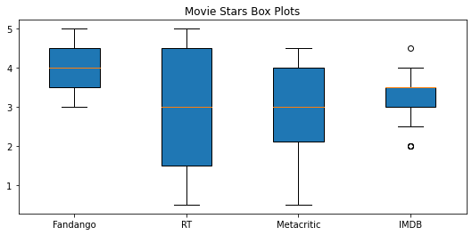

```python
import matplotlib.pyplot as plt

data = fandango[['Fandango_Stars','RT_norm_round','Metacritic_norm_round','IMDB_norm_round']]
labels = ['Fandango', 'RT', 'Metacritic','IMDB']

fig, ax = plt.subplots(nrows=1, ncols=1, figsize=(9, 4))

# rectangular box plot
bplot1 = ax.boxplot(data,
                     patch_artist=True,  # fill with color
                     labels=labels)  # will be used to label x-ticks

ax.set_title('Movie Stars Box Plots')

plt.show()
```

**Q6:** Using `value_counts`, what is the breakdown of counts for the `Fandango_Stars` column sorted by the index? Save this as `Q6A`.

What is the breakdown of relative frequencies (percentages) of the unique values sorted by the index and rounded to 3 decimal places? Check the Pandas `value_counts` documentation for help. Save this as `Q6B`.

```python
#Breakdown of counts for the Fandango_Stars column sorted by index

Q6A = fandango['Fandango_Stars'].value_counts().sort_index(ascending=True)
Q6A
```

```
3.0    12
3.5    27
4.0    41
4.5    55
5.0    11
Name: Fandango_Stars, dtype: int64
```

```python
#Breakdown of relative frequencies (percentages) of the unique values
#Sorted by the index and rounded to 3 decimal places

Q6B = fandango['Fandango_Stars'].value_counts(normalize=True).round(3).sort_index()
Q6B
```

```
3.0    0.082
3.5    0.185
4.0    0.281
4.5    0.377
5.0    0.075
Name: Fandango_Stars, dtype: float64
```

**Q7:** Given the output for `Q6B`, what is the sum of the frequency of values for 4 stars or more? You may hard code this number and round to 2 decimals. Save this as `Q7`.

```python
#The sum of the frequency of values for 4 stars or more
# We can hard code the number and round to 2 decimals.
# Save this as Q7

Q7 = 0.28 + 0.38 + 0.07
Q7
```

```
0.73
```

To give you a comparison to your output above, the sum of frequency values for 4 stars or more for the other sites are as follows:

- RT_norm_round = 0.419
- Metacritic_norm_round = 0.274
- IMDB_norm_round = 0.233

You should see that the output for `Q7` is higher, which is one indication that Fandango rates their movies with higher overall scores.

```python
# Use this, to check discrepancy between the actual ratings and stars shown from Fandango
# fandango['Fandango_Difference'].unique()
```

**Q8:** In the article, the author "normalized" the data by turning the sites with 0-100 ranges to 0-5 ranges. Create a Series called `Q8` that takes the values in the `RottenTomatoes` column and normalizes them to 0-5 ranges. To double check your calculation, your Series should match exactly the `RT_norm` column.

For example: A score of 100 will equal a new score of 5.00, a score of 50 will equal a new score of 2.50, a score of 20 will equal a new score of 1, etc. You should be able to calculate this with one line of code.

```python
#This checks the fandango description and T the max

# fandango.describe().transpose()['max']
```

```python
#Create a Series called Q8 that takes the values in the RottenTomatoes column and normalizes them to 0-5 ranges.
#To double check your calculation, your Series should match exactly the RT_norm column.

Q8 = round(fandango['RottenTomatoes']/20,2)
print(Q8)
```

```
0      3.70
1      4.25
2      4.00
3      0.90
4      0.70
       ...
141    4.35
142    4.85
143    4.85
144    5.00
145    4.35
Name: RottenTomatoes, Length: 146, dtype: float64
```

```python
# double check your above code - This should output 0

Q8 = (fandango['RT_norm'] != Q8).sum()
print(Q8)
```

```
0
```

**Q9:**

- First create a copy of the `fandango` DataFrame and call this `Q9A`.
- Create a new column in the `Q9A` DataFrame called `f_rt_norm` that is the `Fandango_Stars` column minus the `RT_norm_round` column.
- Select only the films where the `RT_norm_round` was higher (the `f_rt_norm` is negative) and save this as `Q9B`.

```python
#Create a copy of the fandango DataFrame and call this Q9A
Q9A = fandango.copy()
Q9A
```

|  | FILM | RottenTomatoes | RottenTomatoes_User | Metacritic | Metacritic_User | IMDB | Fandango_Stars | Fandango_Ratingvalue | RT_norm | RT_user_norm | Metacritic_norm | Metacritic_user_nom | IMDB_norm | RT_norm_round | RT_user_norm_round | Metacritic_norm_round | Metacritic_user_norm_round | IMDB_norm_round | Metacritic_user_vote_count | IMDB_user_vote_count | Fandango_votes | Fandango_Difference |
| --- | --- | --- | --- | --- | --- | --- | --- | --- | --- | --- | --- | --- | --- | --- | --- | --- | --- | --- | --- | --- | --- | --- |
| 0 | Avengers: Age of Ultron (2015) | 74 | 86 | 66 | 7.1 | 7.8 | 5.0 | 4.5 | 3.70 | 4.30 | 3.30 | 3.55 | 3.90 | 3.5 | 4.5 | 3.5 | 3.5 | 4.0 | 1330 | 271107 | 14846 | 0.5 |
| 1 | Cinderella (2015) | 85 | 80 | 67 | 7.5 | 7.1 | 5.0 | 4.5 | 4.25 | 4.00 | 3.35 | 3.75 | 3.55 | 4.5 | 4.0 | 3.5 | 4.0 | 3.5 | 249 | 65709 | 12640 | 0.5 |
| 2 | Ant-Man (2015) | 80 | 90 | 64 | 8.1 | 7.8 | 5.0 | 4.5 | 4.00 | 4.50 | 3.20 | 4.05 | 3.90 | 4.0 | 4.5 | 3.0 | 4.0 | 4.0 | 627 | 103660 | 12055 | 0.5 |
| 3 | Do You Believe? (2015) | 18 | 84 | 22 | 4.7 | 5.4 | 5.0 | 4.5 | 0.90 | 4.20 | 1.10 | 2.35 | 2.70 | 1.0 | 4.0 | 1.0 | 2.5 | 2.5 | 31 | 3136 | 1793 | 0.5 |
| 4 | Hot Tub Time Machine 2 (2015) | 14 | 28 | 29 | 3.4 | 5.1 | 3.5 | 3.0 | 0.70 | 1.40 | 1.45 | 1.70 | 2.55 | 0.5 | 1.5 | 1.5 | 1.5 | 2.5 | 88 | 19560 | 1021 | 0.5 |
| ... | ... | ... | ... | ... | ... | ... | ... | ... | ... | ... | ... | ... | ... | ... | ... | ... | ... | ... | ... | ... | ... | ... |
| 141 | Mr. Holmes (2015) | 87 | 78 | 67 | 7.9 | 7.4 | 4.0 | 4.0 | 4.35 | 3.90 | 3.35 | 3.95 | 3.70 | 4.5 | 4.0 | 3.5 | 4.0 | 3.5 | 33 | 7367 | 1348 | 0.0 |
| 142 | '71 (2015) | 97 | 82 | 83 | 7.5 | 7.2 | 3.5 | 3.5 | 4.85 | 4.10 | 4.15 | 3.75 | 3.60 | 5.0 | 4.0 | 4.0 | 4.0 | 3.5 | 60 | 24116 | 192 | 0.0 |
| 143 | Two Days, One Night (2014) | 97 | 78 | 89 | 8.8 | 7.4 | 3.5 | 3.5 | 4.85 | 3.90 | 4.45 | 4.40 | 3.70 | 5.0 | 4.0 | 4.5 | 4.5 | 3.5 | 123 | 24345 | 118 | 0.0 |
| 144 | Gett: The Trial of Viviane Amsalem (2015) | 100 | 81 | 90 | 7.3 | 7.8 | 3.5 | 3.5 | 5.00 | 4.05 | 4.50 | 3.65 | 3.90 | 5.0 | 4.0 | 4.5 | 3.5 | 4.0 | 19 | 1955 | 59 | 0.0 |
| 145 | Kumiko, The Treasure Hunter (2015) | 87 | 63 | 68 | 6.4 | 6.7 | 3.5 | 3.5 | 4.35 | 3.15 | 3.40 | 3.20 | 3.35 | 4.5 | 3.0 | 3.5 | 3.0 | 3.5 | 19 | 5289 | 41 | 0.0 |

146 rows × 22 columns

```python
#Create a new column in the Q9A DataFrame called f_rt_norm
#that is the Fandango_Stars column minus the RT_norm_round column

Q9A['f_rt_norm'] =  Q9A['Fandango_Stars'] - Q9A['RT_norm_round']                                                                   ### ENTER CODE HERE ###
Q9A
```

|  | FILM | RottenTomatoes | RottenTomatoes_User | Metacritic | Metacritic_User | IMDB | Fandango_Stars | Fandango_Ratingvalue | RT_norm | RT_user_norm | Metacritic_norm | Metacritic_user_nom | IMDB_norm | RT_norm_round | RT_user_norm_round | Metacritic_norm_round | Metacritic_user_norm_round | IMDB_norm_round | Metacritic_user_vote_count | IMDB_user_vote_count | Fandango_votes | Fandango_Difference | f_rt_norm |
| --- | --- | --- | --- | --- | --- | --- | --- | --- | --- | --- | --- | --- | --- | --- | --- | --- | --- | --- | --- | --- | --- | --- | --- |
| 0 | Avengers: Age of Ultron (2015) | 74 | 86 | 66 | 7.1 | 7.8 | 5.0 | 4.5 | 3.70 | 4.30 | 3.30 | 3.55 | 3.90 | 3.5 | 4.5 | 3.5 | 3.5 | 4.0 | 1330 | 271107 | 14846 | 0.5 | 1.5 |
| 1 | Cinderella (2015) | 85 | 80 | 67 | 7.5 | 7.1 | 5.0 | 4.5 | 4.25 | 4.00 | 3.35 | 3.75 | 3.55 | 4.5 | 4.0 | 3.5 | 4.0 | 3.5 | 249 | 65709 | 12640 | 0.5 | 0.5 |
| 2 | Ant-Man (2015) | 80 | 90 | 64 | 8.1 | 7.8 | 5.0 | 4.5 | 4.00 | 4.50 | 3.20 | 4.05 | 3.90 | 4.0 | 4.5 | 3.0 | 4.0 | 4.0 | 627 | 103660 | 12055 | 0.5 | 1.0 |
| 3 | Do You Believe? (2015) | 18 | 84 | 22 | 4.7 | 5.4 | 5.0 | 4.5 | 0.90 | 4.20 | 1.10 | 2.35 | 2.70 | 1.0 | 4.0 | 1.0 | 2.5 | 2.5 | 31 | 3136 | 1793 | 0.5 | 4.0 |
| 4 | Hot Tub Time Machine 2 (2015) | 14 | 28 | 29 | 3.4 | 5.1 | 3.5 | 3.0 | 0.70 | 1.40 | 1.45 | 1.70 | 2.55 | 0.5 | 1.5 | 1.5 | 1.5 | 2.5 | 88 | 19560 | 1021 | 0.5 | 3.0 |
| ... | ... | ... | ... | ... | ... | ... | ... | ... | ... | ... | ... | ... | ... | ... | ... | ... | ... | ... | ... | ... | ... | ... | ... |
| 141 | Mr. Holmes (2015) | 87 | 78 | 67 | 7.9 | 7.4 | 4.0 | 4.0 | 4.35 | 3.90 | 3.35 | 3.95 | 3.70 | 4.5 | 4.0 | 3.5 | 4.0 | 3.5 | 33 | 7367 | 1348 | 0.0 | -0.5 |
| 142 | '71 (2015) | 97 | 82 | 83 | 7.5 | 7.2 | 3.5 | 3.5 | 4.85 | 4.10 | 4.15 | 3.75 | 3.60 | 5.0 | 4.0 | 4.0 | 4.0 | 3.5 | 60 | 24116 | 192 | 0.0 | -1.5 |
| 143 | Two Days, One Night (2014) | 97 | 78 | 89 | 8.8 | 7.4 | 3.5 | 3.5 | 4.85 | 3.90 | 4.45 | 4.40 | 3.70 | 5.0 | 4.0 | 4.5 | 4.5 | 3.5 | 123 | 24345 | 118 | 0.0 | -1.5 |
| 144 | Gett: The Trial of Viviane Amsalem (2015) | 100 | 81 | 90 | 7.3 | 7.8 | 3.5 | 3.5 | 5.00 | 4.05 | 4.50 | 3.65 | 3.90 | 5.0 | 4.0 | 4.5 | 3.5 | 4.0 | 19 | 1955 | 59 | 0.0 | -1.5 |
| 145 | Kumiko, The Treasure Hunter (2015) | 87 | 63 | 68 | 6.4 | 6.7 | 3.5 | 3.5 | 4.35 | 3.15 | 3.40 | 3.20 | 3.35 | 4.5 | 3.0 | 3.5 | 3.0 | 3.5 | 19 | 5289 | 41 | 0.0 | -1.0 |

146 rows × 23 columns

```python
# Select only the films where the `RT_norm_round` was higher
# (the `f_rt_norm` is negative) and save this as `Q9B`

Q9B = Q9A[Q9A['f_rt_norm'] < 0]
Q9B
```

|  | FILM | RottenTomatoes | RottenTomatoes_User | Metacritic | Metacritic_User | IMDB | Fandango_Stars | Fandango_Ratingvalue | RT_norm | RT_user_norm | Metacritic_norm | Metacritic_user_nom | IMDB_norm | RT_norm_round | RT_user_norm_round | Metacritic_norm_round | Metacritic_user_norm_round | IMDB_norm_round | Metacritic_user_vote_count | IMDB_user_vote_count | Fandango_votes | Fandango_Difference | f_rt_norm |
| --- | --- | --- | --- | --- | --- | --- | --- | --- | --- | --- | --- | --- | --- | --- | --- | --- | --- | --- | --- | --- | --- | --- | --- |
| 7 | Top Five (2014) | 86 | 64 | 81 | 6.8 | 6.5 | 4.0 | 3.5 | 4.30 | 3.20 | 4.05 | 3.40 | 3.25 | 4.5 | 3.0 | 4.0 | 3.5 | 3.5 | 124 | 16876 | 3223 | 0.5 | -0.5 |
| 8 | Shaun the Sheep Movie (2015) | 99 | 82 | 81 | 8.8 | 7.4 | 4.5 | 4.0 | 4.95 | 4.10 | 4.05 | 4.40 | 3.70 | 5.0 | 4.0 | 4.0 | 4.5 | 3.5 | 62 | 12227 | 896 | 0.5 | -0.5 |
| 12 | Leviathan (2014) | 99 | 79 | 92 | 7.2 | 7.7 | 4.0 | 3.5 | 4.95 | 3.95 | 4.60 | 3.60 | 3.85 | 5.0 | 4.0 | 4.5 | 3.5 | 4.0 | 145 | 22521 | 64 | 0.5 | -1.0 |
| 28 | Wild Tales (2014) | 96 | 92 | 77 | 8.8 | 8.2 | 4.5 | 4.1 | 4.80 | 4.60 | 3.85 | 4.40 | 4.10 | 5.0 | 4.5 | 4.0 | 4.5 | 4.0 | 107 | 50285 | 235 | 0.4 | -0.5 |
| 30 | Red Army (2015) | 96 | 86 | 82 | 7.4 | 7.7 | 4.5 | 4.1 | 4.80 | 4.30 | 4.10 | 3.70 | 3.85 | 5.0 | 4.5 | 4.0 | 3.5 | 4.0 | 11 | 2275 | 54 | 0.4 | -0.5 |
| 40 | I'll See You In My Dreams (2015) | 94 | 70 | 75 | 6.9 | 6.9 | 4.0 | 3.6 | 4.70 | 3.50 | 3.75 | 3.45 | 3.45 | 4.5 | 3.5 | 4.0 | 3.5 | 3.5 | 14 | 1151 | 281 | 0.4 | -0.5 |
| 41 | Timbuktu (2015) | 99 | 78 | 91 | 6.9 | 7.2 | 4.0 | 3.6 | 4.95 | 3.90 | 4.55 | 3.45 | 3.60 | 5.0 | 4.0 | 4.5 | 3.5 | 3.5 | 37 | 6246 | 74 | 0.4 | -1.0 |
| 42 | About Elly (2015) | 97 | 86 | 87 | 9.6 | 8.2 | 4.0 | 3.6 | 4.85 | 4.30 | 4.35 | 4.80 | 4.10 | 5.0 | 4.5 | 4.5 | 5.0 | 4.0 | 23 | 20659 | 43 | 0.4 | -1.0 |
| 43 | The Diary of a Teenage Girl (2015) | 95 | 81 | 87 | 6.3 | 7.0 | 4.0 | 3.6 | 4.75 | 4.05 | 4.35 | 3.15 | 3.50 | 5.0 | 4.0 | 4.5 | 3.0 | 3.5 | 18 | 1107 | 38 | 0.4 | -1.0 |
| 65 | Birdman (2014) | 92 | 78 | 88 | 8.0 | 7.9 | 4.0 | 3.7 | 4.60 | 3.90 | 4.40 | 4.00 | 3.95 | 4.5 | 4.0 | 4.5 | 4.0 | 4.0 | 1171 | 303505 | 4194 | 0.3 | -0.5 |
| 66 | The Gift (2015) | 93 | 79 | 77 | 8.3 | 7.6 | 4.0 | 3.7 | 4.65 | 3.95 | 3.85 | 4.15 | 3.80 | 4.5 | 4.0 | 4.0 | 4.0 | 4.0 | 121 | 10891 | 2680 | 0.3 | -0.5 |
| 69 | Mr. Turner (2014) | 98 | 56 | 94 | 6.6 | 6.9 | 3.5 | 3.2 | 4.90 | 2.80 | 4.70 | 3.30 | 3.45 | 5.0 | 3.0 | 4.5 | 3.5 | 3.5 | 98 | 13296 | 290 | 0.3 | -1.5 |
| 70 | Seymour: An Introduction (2015) | 100 | 87 | 83 | 6.0 | 7.7 | 4.5 | 4.2 | 5.00 | 4.35 | 4.15 | 3.00 | 3.85 | 5.0 | 4.5 | 4.0 | 3.0 | 4.0 | 4 | 243 | 41 | 0.3 | -0.5 |
| 88 | Mad Max: Fury Road (2015) | 97 | 88 | 89 | 8.7 | 8.3 | 4.5 | 4.3 | 4.85 | 4.40 | 4.45 | 4.35 | 4.15 | 5.0 | 4.5 | 4.5 | 4.5 | 4.0 | 2375 | 292023 | 10509 | 0.2 | -0.5 |
| 90 | The SpongeBob Movie: Sponge Out of Water (2015) | 78 | 55 | 62 | 6.5 | 6.1 | 3.5 | 3.3 | 3.90 | 2.75 | 3.10 | 3.25 | 3.05 | 4.0 | 3.0 | 3.0 | 3.5 | 3.0 | 196 | 26046 | 4493 | 0.2 | -0.5 |
| 91 | Paddington (2015) | 98 | 81 | 77 | 8.2 | 7.2 | 4.5 | 4.3 | 4.90 | 4.05 | 3.85 | 4.10 | 3.60 | 5.0 | 4.0 | 4.0 | 4.0 | 3.5 | 149 | 38593 | 4045 | 0.2 | -0.5 |
| 93 | What We Do in the Shadows (2015) | 96 | 86 | 75 | 8.3 | 7.6 | 4.5 | 4.3 | 4.80 | 4.30 | 3.75 | 4.15 | 3.80 | 5.0 | 4.5 | 4.0 | 4.0 | 4.0 | 69 | 39561 | 259 | 0.2 | -0.5 |
| 94 | The Overnight (2015) | 82 | 65 | 65 | 8.6 | 6.9 | 3.5 | 3.3 | 4.10 | 3.25 | 3.25 | 4.30 | 3.45 | 4.0 | 3.5 | 3.5 | 4.5 | 3.5 | 13 | 867 | 110 | 0.2 | -0.5 |
| 95 | The Salt of the Earth (2015) | 96 | 90 | 83 | 7.8 | 8.4 | 4.5 | 4.3 | 4.80 | 4.50 | 4.15 | 3.90 | 4.20 | 5.0 | 4.5 | 4.0 | 4.0 | 4.0 | 13 | 6605 | 83 | 0.2 | -0.5 |
| 96 | Song of the Sea (2014) | 99 | 92 | 86 | 8.2 | 8.2 | 4.5 | 4.3 | 4.95 | 4.60 | 4.30 | 4.10 | 4.10 | 5.0 | 4.5 | 4.5 | 4.0 | 4.0 | 62 | 14067 | 66 | 0.2 | -0.5 |
| 112 | It Follows (2015) | 96 | 65 | 83 | 7.5 | 6.9 | 3.0 | 2.9 | 4.80 | 3.25 | 4.15 | 3.75 | 3.45 | 5.0 | 3.5 | 4.0 | 4.0 | 3.5 | 551 | 64656 | 2097 | 0.1 | -2.0 |
| 113 | Inherent Vice (2014) | 73 | 52 | 81 | 7.4 | 6.7 | 3.0 | 2.9 | 3.65 | 2.60 | 4.05 | 3.70 | 3.35 | 3.5 | 2.5 | 4.0 | 3.5 | 3.5 | 286 | 44711 | 1078 | 0.1 | -0.5 |
| 114 | A Most Violent Year (2014) | 90 | 69 | 79 | 7.0 | 7.1 | 3.5 | 3.4 | 4.50 | 3.45 | 3.95 | 3.50 | 3.55 | 4.5 | 3.5 | 4.0 | 3.5 | 3.5 | 133 | 32166 | 675 | 0.1 | -1.0 |
| 115 | While We're Young (2015) | 83 | 52 | 76 | 6.7 | 6.4 | 3.0 | 2.9 | 4.15 | 2.60 | 3.80 | 3.35 | 3.20 | 4.0 | 2.5 | 4.0 | 3.5 | 3.0 | 65 | 17647 | 449 | 0.1 | -1.0 |
| 116 | Clouds of Sils Maria (2015) | 89 | 67 | 78 | 7.1 | 6.8 | 3.5 | 3.4 | 4.45 | 3.35 | 3.90 | 3.55 | 3.40 | 4.5 | 3.5 | 4.0 | 3.5 | 3.5 | 36 | 11392 | 162 | 0.1 | -1.0 |
| 119 | Phoenix (2015) | 99 | 81 | 91 | 8.0 | 7.2 | 3.5 | 3.4 | 4.95 | 4.05 | 4.55 | 4.00 | 3.60 | 5.0 | 4.0 | 4.5 | 4.0 | 3.5 | 21 | 3687 | 70 | 0.1 | -1.5 |
| 120 | The Wolfpack (2015) | 84 | 73 | 75 | 7.0 | 7.1 | 3.5 | 3.4 | 4.20 | 3.65 | 3.75 | 3.50 | 3.55 | 4.0 | 3.5 | 4.0 | 3.5 | 3.5 | 8 | 1488 | 66 | 0.1 | -0.5 |
| 122 | Tangerine (2015) | 95 | 86 | 86 | 7.3 | 7.4 | 4.0 | 3.9 | 4.75 | 4.30 | 4.30 | 3.65 | 3.70 | 5.0 | 4.5 | 4.5 | 3.5 | 3.5 | 14 | 696 | 36 | 0.1 | -1.0 |
| 129 | Amy (2015) | 97 | 91 | 85 | 8.8 | 8.0 | 4.5 | 4.4 | 4.85 | 4.55 | 4.25 | 4.40 | 4.00 | 5.0 | 4.5 | 4.5 | 4.5 | 4.0 | 60 | 5630 | 729 | 0.1 | -0.5 |
| 140 | Inside Out (2015) | 98 | 90 | 94 | 8.9 | 8.6 | 4.5 | 4.5 | 4.90 | 4.50 | 4.70 | 4.45 | 4.30 | 5.0 | 4.5 | 4.5 | 4.5 | 4.5 | 807 | 96252 | 15749 | 0.0 | -0.5 |
| 141 | Mr. Holmes (2015) | 87 | 78 | 67 | 7.9 | 7.4 | 4.0 | 4.0 | 4.35 | 3.90 | 3.35 | 3.95 | 3.70 | 4.5 | 4.0 | 3.5 | 4.0 | 3.5 | 33 | 7367 | 1348 | 0.0 | -0.5 |
| 142 | '71 (2015) | 97 | 82 | 83 | 7.5 | 7.2 | 3.5 | 3.5 | 4.85 | 4.10 | 4.15 | 3.75 | 3.60 | 5.0 | 4.0 | 4.0 | 4.0 | 3.5 | 60 | 24116 | 192 | 0.0 | -1.5 |
| 143 | Two Days, One Night (2014) | 97 | 78 | 89 | 8.8 | 7.4 | 3.5 | 3.5 | 4.85 | 3.90 | 4.45 | 4.40 | 3.70 | 5.0 | 4.0 | 4.5 | 4.5 | 3.5 | 123 | 24345 | 118 | 0.0 | -1.5 |
| 144 | Gett: The Trial of Viviane Amsalem (2015) | 100 | 81 | 90 | 7.3 | 7.8 | 3.5 | 3.5 | 5.00 | 4.05 | 4.50 | 3.65 | 3.90 | 5.0 | 4.0 | 4.5 | 3.5 | 4.0 | 19 | 1955 | 59 | 0.0 | -1.5 |
| 145 | Kumiko, The Treasure Hunter (2015) | 87 | 63 | 68 | 6.4 | 6.7 | 3.5 | 3.5 | 4.35 | 3.15 | 3.40 | 3.20 | 3.35 | 4.5 | 3.0 | 3.5 | 3.0 | 3.5 | 19 | 5289 | 41 | 0.0 | -1.0 |

**Q10 & Q11:**

- Perform the same action as above creating two new columns in `Q9A` by subtracting the `Metacritic_norm_round` and `IMDB_norm_round` from `Fandango_Stars` and calling the columns `f_mc_norm` and `f_imdb_norm` respectively and in that order.
- Select the rows where `f_mc_norm` is negative and save this as `Q10`.
- Select the rows where `f_imdb_norm` is negative and save this as `Q11`.

```python
#creating two new columns in Q9A by subtracting:
#The Metacritic_norm_round and IMDB_norm_round from Fandango_Stars and
#Call the columns f_mc_norm and f_imdb_norm respectively and in that order

Q9A['f_mc_norm'] =  Q9A['Fandango_Stars'] - Q9A['Metacritic_norm_round']
Q9A['f_imdb_norm'] =  Q9A['Fandango_Stars'] - Q9A['IMDB_norm_round']
Q9A
```

|  | FILM | RottenTomatoes | RottenTomatoes_User | Metacritic | Metacritic_User | IMDB | Fandango_Stars | Fandango_Ratingvalue | RT_norm | RT_user_norm | Metacritic_norm | Metacritic_user_nom | IMDB_norm | RT_norm_round | RT_user_norm_round | Metacritic_norm_round | Metacritic_user_norm_round | IMDB_norm_round | Metacritic_user_vote_count | IMDB_user_vote_count | Fandango_votes | Fandango_Difference | f_rt_norm | f_mc_norm | f_imdb_norm |
| --- | --- | --- | --- | --- | --- | --- | --- | --- | --- | --- | --- | --- | --- | --- | --- | --- | --- | --- | --- | --- | --- | --- | --- | --- | --- |
| 0 | Avengers: Age of Ultron (2015) | 74 | 86 | 66 | 7.1 | 7.8 | 5.0 | 4.5 | 3.70 | 4.30 | 3.30 | 3.55 | 3.90 | 3.5 | 4.5 | 3.5 | 3.5 | 4.0 | 1330 | 271107 | 14846 | 0.5 | 1.5 | 1.5 | 1.0 |
| 1 | Cinderella (2015) | 85 | 80 | 67 | 7.5 | 7.1 | 5.0 | 4.5 | 4.25 | 4.00 | 3.35 | 3.75 | 3.55 | 4.5 | 4.0 | 3.5 | 4.0 | 3.5 | 249 | 65709 | 12640 | 0.5 | 0.5 | 1.5 | 1.5 |
| 2 | Ant-Man (2015) | 80 | 90 | 64 | 8.1 | 7.8 | 5.0 | 4.5 | 4.00 | 4.50 | 3.20 | 4.05 | 3.90 | 4.0 | 4.5 | 3.0 | 4.0 | 4.0 | 627 | 103660 | 12055 | 0.5 | 1.0 | 2.0 | 1.0 |
| 3 | Do You Believe? (2015) | 18 | 84 | 22 | 4.7 | 5.4 | 5.0 | 4.5 | 0.90 | 4.20 | 1.10 | 2.35 | 2.70 | 1.0 | 4.0 | 1.0 | 2.5 | 2.5 | 31 | 3136 | 1793 | 0.5 | 4.0 | 4.0 | 2.5 |
| 4 | Hot Tub Time Machine 2 (2015) | 14 | 28 | 29 | 3.4 | 5.1 | 3.5 | 3.0 | 0.70 | 1.40 | 1.45 | 1.70 | 2.55 | 0.5 | 1.5 | 1.5 | 1.5 | 2.5 | 88 | 19560 | 1021 | 0.5 | 3.0 | 2.0 | 1.0 |
| ... | ... | ... | ... | ... | ... | ... | ... | ... | ... | ... | ... | ... | ... | ... | ... | ... | ... | ... | ... | ... | ... | ... | ... | ... | ... |
| 141 | Mr. Holmes (2015) | 87 | 78 | 67 | 7.9 | 7.4 | 4.0 | 4.0 | 4.35 | 3.90 | 3.35 | 3.95 | 3.70 | 4.5 | 4.0 | 3.5 | 4.0 | 3.5 | 33 | 7367 | 1348 | 0.0 | -0.5 | 0.5 | 0.5 |
| 142 | '71 (2015) | 97 | 82 | 83 | 7.5 | 7.2 | 3.5 | 3.5 | 4.85 | 4.10 | 4.15 | 3.75 | 3.60 | 5.0 | 4.0 | 4.0 | 4.0 | 3.5 | 60 | 24116 | 192 | 0.0 | -1.5 | -0.5 | 0.0 |
| 143 | Two Days, One Night (2014) | 97 | 78 | 89 | 8.8 | 7.4 | 3.5 | 3.5 | 4.85 | 3.90 | 4.45 | 4.40 | 3.70 | 5.0 | 4.0 | 4.5 | 4.5 | 3.5 | 123 | 24345 | 118 | 0.0 | -1.5 | -1.0 | 0.0 |
| 144 | Gett: The Trial of Viviane Amsalem (2015) | 100 | 81 | 90 | 7.3 | 7.8 | 3.5 | 3.5 | 5.00 | 4.05 | 4.50 | 3.65 | 3.90 | 5.0 | 4.0 | 4.5 | 3.5 | 4.0 | 19 | 1955 | 59 | 0.0 | -1.5 | -1.0 | -0.5 |
| 145 | Kumiko, The Treasure Hunter (2015) | 87 | 63 | 68 | 6.4 | 6.7 | 3.5 | 3.5 | 4.35 | 3.15 | 3.40 | 3.20 | 3.35 | 4.5 | 3.0 | 3.5 | 3.0 | 3.5 | 19 | 5289 | 41 | 0.0 | -1.0 | 0.0 | 0.0 |

146 rows × 25 columns

```python
#Select the rows where f_mc_norm is negative
#And save this as Q10

Q10 = Q9A[Q9A['f_mc_norm'] < 0]
Q10
```

|  | FILM | RottenTomatoes | RottenTomatoes_User | Metacritic | Metacritic_User | IMDB | Fandango_Stars | Fandango_Ratingvalue | RT_norm | RT_user_norm | Metacritic_norm | Metacritic_user_nom | IMDB_norm | RT_norm_round | RT_user_norm_round | Metacritic_norm_round | Metacritic_user_norm_round | IMDB_norm_round | Metacritic_user_vote_count | IMDB_user_vote_count | Fandango_votes | Fandango_Difference | f_rt_norm | f_mc_norm | f_imdb_norm |
| --- | --- | --- | --- | --- | --- | --- | --- | --- | --- | --- | --- | --- | --- | --- | --- | --- | --- | --- | --- | --- | --- | --- | --- | --- | --- |
| 12 | Leviathan (2014) | 99 | 79 | 92 | 7.2 | 7.7 | 4.0 | 3.5 | 4.95 | 3.95 | 4.60 | 3.60 | 3.85 | 5.0 | 4.0 | 4.5 | 3.5 | 4.0 | 145 | 22521 | 64 | 0.5 | -1.0 | -0.5 | 0.0 |
| 41 | Timbuktu (2015) | 99 | 78 | 91 | 6.9 | 7.2 | 4.0 | 3.6 | 4.95 | 3.90 | 4.55 | 3.45 | 3.60 | 5.0 | 4.0 | 4.5 | 3.5 | 3.5 | 37 | 6246 | 74 | 0.4 | -1.0 | -0.5 | 0.5 |
| 42 | About Elly (2015) | 97 | 86 | 87 | 9.6 | 8.2 | 4.0 | 3.6 | 4.85 | 4.30 | 4.35 | 4.80 | 4.10 | 5.0 | 4.5 | 4.5 | 5.0 | 4.0 | 23 | 20659 | 43 | 0.4 | -1.0 | -0.5 | 0.0 |
| 43 | The Diary of a Teenage Girl (2015) | 95 | 81 | 87 | 6.3 | 7.0 | 4.0 | 3.6 | 4.75 | 4.05 | 4.35 | 3.15 | 3.50 | 5.0 | 4.0 | 4.5 | 3.0 | 3.5 | 18 | 1107 | 38 | 0.4 | -1.0 | -0.5 | 0.5 |
| 65 | Birdman (2014) | 92 | 78 | 88 | 8.0 | 7.9 | 4.0 | 3.7 | 4.60 | 3.90 | 4.40 | 4.00 | 3.95 | 4.5 | 4.0 | 4.5 | 4.0 | 4.0 | 1171 | 303505 | 4194 | 0.3 | -0.5 | -0.5 | 0.0 |
| 69 | Mr. Turner (2014) | 98 | 56 | 94 | 6.6 | 6.9 | 3.5 | 3.2 | 4.90 | 2.80 | 4.70 | 3.30 | 3.45 | 5.0 | 3.0 | 4.5 | 3.5 | 3.5 | 98 | 13296 | 290 | 0.3 | -1.5 | -1.0 | 0.0 |
| 112 | It Follows (2015) | 96 | 65 | 83 | 7.5 | 6.9 | 3.0 | 2.9 | 4.80 | 3.25 | 4.15 | 3.75 | 3.45 | 5.0 | 3.5 | 4.0 | 4.0 | 3.5 | 551 | 64656 | 2097 | 0.1 | -2.0 | -1.0 | -0.5 |
| 113 | Inherent Vice (2014) | 73 | 52 | 81 | 7.4 | 6.7 | 3.0 | 2.9 | 3.65 | 2.60 | 4.05 | 3.70 | 3.35 | 3.5 | 2.5 | 4.0 | 3.5 | 3.5 | 286 | 44711 | 1078 | 0.1 | -0.5 | -1.0 | -0.5 |
| 114 | A Most Violent Year (2014) | 90 | 69 | 79 | 7.0 | 7.1 | 3.5 | 3.4 | 4.50 | 3.45 | 3.95 | 3.50 | 3.55 | 4.5 | 3.5 | 4.0 | 3.5 | 3.5 | 133 | 32166 | 675 | 0.1 | -1.0 | -0.5 | 0.0 |
| 115 | While We're Young (2015) | 83 | 52 | 76 | 6.7 | 6.4 | 3.0 | 2.9 | 4.15 | 2.60 | 3.80 | 3.35 | 3.20 | 4.0 | 2.5 | 4.0 | 3.5 | 3.0 | 65 | 17647 | 449 | 0.1 | -1.0 | -1.0 | 0.0 |
| 116 | Clouds of Sils Maria (2015) | 89 | 67 | 78 | 7.1 | 6.8 | 3.5 | 3.4 | 4.45 | 3.35 | 3.90 | 3.55 | 3.40 | 4.5 | 3.5 | 4.0 | 3.5 | 3.5 | 36 | 11392 | 162 | 0.1 | -1.0 | -0.5 | 0.0 |
| 119 | Phoenix (2015) | 99 | 81 | 91 | 8.0 | 7.2 | 3.5 | 3.4 | 4.95 | 4.05 | 4.55 | 4.00 | 3.60 | 5.0 | 4.0 | 4.5 | 4.0 | 3.5 | 21 | 3687 | 70 | 0.1 | -1.5 | -1.0 | 0.0 |
| 120 | The Wolfpack (2015) | 84 | 73 | 75 | 7.0 | 7.1 | 3.5 | 3.4 | 4.20 | 3.65 | 3.75 | 3.50 | 3.55 | 4.0 | 3.5 | 4.0 | 3.5 | 3.5 | 8 | 1488 | 66 | 0.1 | -0.5 | -0.5 | 0.0 |
| 122 | Tangerine (2015) | 95 | 86 | 86 | 7.3 | 7.4 | 4.0 | 3.9 | 4.75 | 4.30 | 4.30 | 3.65 | 3.70 | 5.0 | 4.5 | 4.5 | 3.5 | 3.5 | 14 | 696 | 36 | 0.1 | -1.0 | -0.5 | 0.5 |
| 142 | '71 (2015) | 97 | 82 | 83 | 7.5 | 7.2 | 3.5 | 3.5 | 4.85 | 4.10 | 4.15 | 3.75 | 3.60 | 5.0 | 4.0 | 4.0 | 4.0 | 3.5 | 60 | 24116 | 192 | 0.0 | -1.5 | -0.5 | 0.0 |
| 143 | Two Days, One Night (2014) | 97 | 78 | 89 | 8.8 | 7.4 | 3.5 | 3.5 | 4.85 | 3.90 | 4.45 | 4.40 | 3.70 | 5.0 | 4.0 | 4.5 | 4.5 | 3.5 | 123 | 24345 | 118 | 0.0 | -1.5 | -1.0 | 0.0 |
| 144 | Gett: The Trial of Viviane Amsalem (2015) | 100 | 81 | 90 | 7.3 | 7.8 | 3.5 | 3.5 | 5.00 | 4.05 | 4.50 | 3.65 | 3.90 | 5.0 | 4.0 | 4.5 | 3.5 | 4.0 | 19 | 1955 | 59 | 0.0 | -1.5 | -1.0 | -0.5 |

```python
#Select the rows where f_imdb_norm is negative
#And save this as Q11
Q11 = Q9A[Q9A['f_imdb_norm'] < 0]
Q11
```

|  | FILM | RottenTomatoes | RottenTomatoes_User | Metacritic | Metacritic_User | IMDB | Fandango_Stars | Fandango_Ratingvalue | RT_norm | RT_user_norm | Metacritic_norm | Metacritic_user_nom | IMDB_norm | RT_norm_round | RT_user_norm_round | Metacritic_norm_round | Metacritic_user_norm_round | IMDB_norm_round | Metacritic_user_vote_count | IMDB_user_vote_count | Fandango_votes | Fandango_Difference | f_rt_norm | f_mc_norm | f_imdb_norm |
| --- | --- | --- | --- | --- | --- | --- | --- | --- | --- | --- | --- | --- | --- | --- | --- | --- | --- | --- | --- | --- | --- | --- | --- | --- | --- |
| 112 | It Follows (2015) | 96 | 65 | 83 | 7.5 | 6.9 | 3.0 | 2.9 | 4.80 | 3.25 | 4.15 | 3.75 | 3.45 | 5.0 | 3.5 | 4.0 | 4.0 | 3.5 | 551 | 64656 | 2097 | 0.1 | -2.0 | -1.0 | -0.5 |
| 113 | Inherent Vice (2014) | 73 | 52 | 81 | 7.4 | 6.7 | 3.0 | 2.9 | 3.65 | 2.60 | 4.05 | 3.70 | 3.35 | 3.5 | 2.5 | 4.0 | 3.5 | 3.5 | 286 | 44711 | 1078 | 0.1 | -0.5 | -1.0 | -0.5 |
| 144 | Gett: The Trial of Viviane Amsalem (2015) | 100 | 81 | 90 | 7.3 | 7.8 | 3.5 | 3.5 | 5.00 | 4.05 | 4.50 | 3.65 | 3.90 | 5.0 | 4.0 | 4.5 | 3.5 | 4.0 | 19 | 1955 | 59 | 0.0 | -1.5 | -1.0 | -0.5 |

**Q12:** What are the means of the `f_rt_norm`, `f_mc_norm`, and `f_imdb_norm` columns rounded to 3 decimal places. Put these three averages into a list called `Q12`.

```python
#Compute the means of the f_rt_norm, f_mc_norm, and f_imdb_norm columns rounded to 3 decimal places.
# Put these three averages into a list called Q12.
#First we change the pd df to np.array, get the means and then change np.array to list

Q12 = Q9A[['f_rt_norm', 'f_mc_norm','f_imdb_norm']].to_numpy() #Change to numpy
Q12 = np.mean(Q12, axis = 0).tolist()    #convert to list
Q12 = [round(elem,3) for elem in Q12 ]   #round to 3 deciamal places
Q12
```

```
[1.024, 1.116, 0.709]
```

**Q13:** What are the median values of the `f_rt_norm`, `f_mc_norm`, and `f_imdb_norm` columns. Put these three median values into a list called `Q13`.

```python
#Compute the median values of the f_rt_norm, f_mc_norm, and f_imdb_norm columns
#Put the three median values into a list called Q13
#First we change the pd df to np.array, get the means
# We then finally change np.array into list

Q13 = Q9A[['f_rt_norm', 'f_mc_norm','f_imdb_norm']].to_numpy() #Change to numpy
Q13 = np.median(Q13, axis = 0).tolist()    #convert to list
Q13
```

```
[1.0, 1.0, 0.5]
```

**Q14:** The article mentions the movie `Avengers: Age of Ultron (2015)`. Select this film in the `fandango` data and save this as `Q14`.

```python
# Select the movie 'Avengers: Age of Ultron (2015)' in the fandango data
# And save this as Q14

Q14 = fandango[fandango['FILM'] == 'Avengers: Age of Ultron (2015)']
Q14
```

|  | FILM | RottenTomatoes | RottenTomatoes_User | Metacritic | Metacritic_User | IMDB | Fandango_Stars | Fandango_Ratingvalue | RT_norm | RT_user_norm | Metacritic_norm | Metacritic_user_nom | IMDB_norm | RT_norm_round | RT_user_norm_round | Metacritic_norm_round | Metacritic_user_norm_round | IMDB_norm_round | Metacritic_user_vote_count | IMDB_user_vote_count | Fandango_votes | Fandango_Difference |
| --- | --- | --- | --- | --- | --- | --- | --- | --- | --- | --- | --- | --- | --- | --- | --- | --- | --- | --- | --- | --- | --- | --- |
| 0 | Avengers: Age of Ultron (2015) | 74 | 86 | 66 | 7.1 | 7.8 | 5.0 | 4.5 | 3.7 | 4.3 | 3.3 | 3.55 | 3.9 | 3.5 | 4.5 | 3.5 | 3.5 | 4.0 | 1330 | 271107 | 14846 | 0.5 |

**Q15:** Select only the `FILM`, `Fandango_Stars`, and `Fandango_Ratingvalue` columns from `Q14` and save it as `Q15`.

```python
# Select only the `FILM`, `Fandango_Stars`, and `Fandango_Ratingvalue` columns from `Q14`
# And save it as `Q15`

Q15 = Q14[['FILM','Fandango_Stars','Fandango_Ratingvalue']]
Q15
```

|  | FILM | Fandango_Stars | Fandango_Ratingvalue |
| --- | --- | --- | --- |
| 0 | Avengers: Age of Ultron (2015) | 5.0 | 4.5 |

As was mentioned in the article, you can see that this movie gained an entire half star between the actual rating score and the stars score.

**Q16:** Index the `fandango` DataFrame and select all movies with an `IMDB` score of 8 or higher. Save this DataFrame as `Q16`.

```python
# Index the fandango DataFrame

# fandango.set_index('FILM')  ---Already indexed on Q1

# Select all movies with an IMDB score of 8 or higher
# Save the DataFrame as Q16

fandango_IMDB_scores  = fandango[fandango['IMDB']>= 8]
Q16 = fandango_IMDB_scores
Q16
```

|  | FILM | RottenTomatoes | RottenTomatoes_User | Metacritic | Metacritic_User | IMDB | Fandango_Stars | Fandango_Ratingvalue | RT_norm | RT_user_norm | Metacritic_norm | Metacritic_user_nom | IMDB_norm | RT_norm_round | RT_user_norm_round | Metacritic_norm_round | Metacritic_user_norm_round | IMDB_norm_round | Metacritic_user_vote_count | IMDB_user_vote_count | Fandango_votes | Fandango_Difference |
| --- | --- | --- | --- | --- | --- | --- | --- | --- | --- | --- | --- | --- | --- | --- | --- | --- | --- | --- | --- | --- | --- | --- |
| 14 | The Imitation Game (2014) | 90 | 92 | 73 | 8.2 | 8.1 | 5.0 | 4.6 | 4.50 | 4.60 | 3.65 | 4.10 | 4.05 | 4.5 | 4.5 | 3.5 | 4.0 | 4.0 | 566 | 334164 | 8055 | 0.4 |
| 28 | Wild Tales (2014) | 96 | 92 | 77 | 8.8 | 8.2 | 4.5 | 4.1 | 4.80 | 4.60 | 3.85 | 4.40 | 4.10 | 5.0 | 4.5 | 4.0 | 4.5 | 4.0 | 107 | 50285 | 235 | 0.4 |
| 42 | About Elly (2015) | 97 | 86 | 87 | 9.6 | 8.2 | 4.0 | 3.6 | 4.85 | 4.30 | 4.35 | 4.80 | 4.10 | 5.0 | 4.5 | 4.5 | 5.0 | 4.0 | 23 | 20659 | 43 | 0.4 |
| 76 | Straight Outta Compton (2015) | 90 | 94 | 72 | 7.3 | 8.4 | 5.0 | 4.8 | 4.50 | 4.70 | 3.60 | 3.65 | 4.20 | 4.5 | 4.5 | 3.5 | 3.5 | 4.0 | 90 | 15982 | 8096 | 0.2 |
| 86 | Me and Earl and The Dying Girl (2015) | 81 | 89 | 74 | 8.4 | 8.2 | 4.5 | 4.3 | 4.05 | 4.45 | 3.70 | 4.20 | 4.10 | 4.0 | 4.5 | 3.5 | 4.0 | 4.0 | 41 | 5269 | 624 | 0.2 |
| 88 | Mad Max: Fury Road (2015) | 97 | 88 | 89 | 8.7 | 8.3 | 4.5 | 4.3 | 4.85 | 4.40 | 4.45 | 4.35 | 4.15 | 5.0 | 4.5 | 4.5 | 4.5 | 4.0 | 2375 | 292023 | 10509 | 0.2 |
| 95 | The Salt of the Earth (2015) | 96 | 90 | 83 | 7.8 | 8.4 | 4.5 | 4.3 | 4.80 | 4.50 | 4.15 | 3.90 | 4.20 | 5.0 | 4.5 | 4.0 | 4.0 | 4.0 | 13 | 6605 | 83 | 0.2 |
| 96 | Song of the Sea (2014) | 99 | 92 | 86 | 8.2 | 8.2 | 4.5 | 4.3 | 4.95 | 4.60 | 4.30 | 4.10 | 4.10 | 5.0 | 4.5 | 4.5 | 4.0 | 4.0 | 62 | 14067 | 66 | 0.2 |
| 129 | Amy (2015) | 97 | 91 | 85 | 8.8 | 8.0 | 4.5 | 4.4 | 4.85 | 4.55 | 4.25 | 4.40 | 4.00 | 5.0 | 4.5 | 4.5 | 4.5 | 4.0 | 60 | 5630 | 729 | 0.1 |
| 140 | Inside Out (2015) | 98 | 90 | 94 | 8.9 | 8.6 | 4.5 | 4.5 | 4.90 | 4.50 | 4.70 | 4.45 | 4.30 | 5.0 | 4.5 | 4.5 | 4.5 | 4.5 | 807 | 96252 | 15749 | 0.0 |

**Q17:** Index the `fandango` DataFrame and select all movies with a `RottenTomatoes` score of 100. Save this DataFrame as `Q17`.

```python
#Index the fandango DataFrame

# fandango = fandango.set_index('FILM')    --fandango df Already indexed on Q1

# Select all movies with a RottenTomatoes score of 100
# Save this DataFrame as Q17

fandango_RT_scores_100 = fandango[fandango['RottenTomatoes']==100]
Q17 = fandango_RT_scores_100
Q17
```

|  | FILM | RottenTomatoes | RottenTomatoes_User | Metacritic | Metacritic_User | IMDB | Fandango_Stars | Fandango_Ratingvalue | RT_norm | RT_user_norm | Metacritic_norm | Metacritic_user_nom | IMDB_norm | RT_norm_round | RT_user_norm_round | Metacritic_norm_round | Metacritic_user_norm_round | IMDB_norm_round | Metacritic_user_vote_count | IMDB_user_vote_count | Fandango_votes | Fandango_Difference |
| --- | --- | --- | --- | --- | --- | --- | --- | --- | --- | --- | --- | --- | --- | --- | --- | --- | --- | --- | --- | --- | --- | --- |
| 70 | Seymour: An Introduction (2015) | 100 | 87 | 83 | 6.0 | 7.7 | 4.5 | 4.2 | 5.0 | 4.35 | 4.15 | 3.00 | 3.85 | 5.0 | 4.5 | 4.0 | 3.0 | 4.0 | 4 | 243 | 41 | 0.3 |
| 144 | Gett: The Trial of Viviane Amsalem (2015) | 100 | 81 | 90 | 7.3 | 7.8 | 3.5 | 3.5 | 5.0 | 4.05 | 4.50 | 3.65 | 3.90 | 5.0 | 4.0 | 4.5 | 3.5 | 4.0 | 19 | 1955 | 59 | 0.0 |

**Q18:** Index the `fandango` DataFrame and select all movies with a `Metacritic` score less than 20. Save this DataFrame as `Q18`.

```python
#Index the fandango DataFrame

# fandango = fandango.set_index('FILM')  --fandango df Already indexed on Q1

#Select all movies with a Metacritic score less than 20
# Save the DataFrame as Q18

fandango_Metacritic_scores = fandango[fandango['Metacritic'] < 20]
Q18 = fandango_Metacritic_scores
Q18
```

|  | FILM | RottenTomatoes | RottenTomatoes_User | Metacritic | Metacritic_User | IMDB | Fandango_Stars | Fandango_Ratingvalue | RT_norm | RT_user_norm | Metacritic_norm | Metacritic_user_nom | IMDB_norm | RT_norm_round | RT_user_norm_round | Metacritic_norm_round | Metacritic_user_norm_round | IMDB_norm_round | Metacritic_user_vote_count | IMDB_user_vote_count | Fandango_votes | Fandango_Difference |
| --- | --- | --- | --- | --- | --- | --- | --- | --- | --- | --- | --- | --- | --- | --- | --- | --- | --- | --- | --- | --- | --- | --- |
| 133 | Paul Blart: Mall Cop 2 (2015) | 5 | 36 | 13 | 2.4 | 4.3 | 3.5 | 3.5 | 0.25 | 1.8 | 0.65 | 1.2 | 2.15 | 0.5 | 2.0 | 0.5 | 1.0 | 2.0 | 211 | 15004 | 3054 | 0.0 |

**Q19:** Index the `fandango` DataFrame and select all movies with a `RottenTomatoes_User` greater than 85, `Metacritic_User` score greater than 8.5, and an `IMDB` score greater than 8.5. Save this DataFrame as `Q19`.

```python
### ////Note: will re do Q19 ////

#Index the fandango DataFrame

# fandango = fandango.set_index('FILM')  --fandango df Already indexed on Q1
```

```python
# 1/ Select all movies with a RottenTomatoes_User greater than 85,

Q19 = fandango[(fandango['RottenTomatoes_User'] > 85) & (fandango['IMDB'] > 8.5) & (fandango['Metacritic_User'] > 8.5)]
Q19
```

|  | FILM | RottenTomatoes | RottenTomatoes_User | Metacritic | Metacritic_User | IMDB | Fandango_Stars | Fandango_Ratingvalue | RT_norm | RT_user_norm | Metacritic_norm | Metacritic_user_nom | IMDB_norm | RT_norm_round | RT_user_norm_round | Metacritic_norm_round | Metacritic_user_norm_round | IMDB_norm_round | Metacritic_user_vote_count | IMDB_user_vote_count | Fandango_votes | Fandango_Difference |
| --- | --- | --- | --- | --- | --- | --- | --- | --- | --- | --- | --- | --- | --- | --- | --- | --- | --- | --- | --- | --- | --- | --- |
| 140 | Inside Out (2015) | 98 | 90 | 94 | 8.9 | 8.6 | 4.5 | 4.5 | 4.9 | 4.5 | 4.7 | 4.45 | 4.3 | 5.0 | 4.5 | 4.5 | 4.5 | 4.5 | 807 | 96252 | 15749 | 0.0 |

**Q20:** Sort the `fandango` DataFrame by the number of Fandango votes (in descending order) and save this new DataFrame as `fandango_sorted_value`. Select only the films with more than 30,000 votes and save as `Q20` in descending order by number of votes.

```python
#Index the fandango DataFrame

# fandango = fandango.set_index('FILM') --fandango df Already indexed on Q1

fandango_sorted_value = fandango.sort_values(by='Fandango_votes', ascending=False)
Q20 = fandango_sorted_value[fandango_sorted_value['Fandango_votes'] > 30000]
print(Q20)
```

```
                            FILM  RottenTomatoes  RottenTomatoes_User  \
97   Fifty Shades of Grey (2015)              25                   42
130        Jurassic World (2015)              71                   81
72        American Sniper (2015)              72                   85
73              Furious 7 (2015)              81                   84

     Metacritic  Metacritic_User  IMDB  Fandango_Stars  Fandango_Ratingvalue  \
97           46              3.2   4.2             4.0                   3.9
130          59              7.0   7.3             4.5                   4.5
72           72              6.6   7.4             5.0                   4.8
73           67              6.8   7.4             5.0                   4.8

     RT_norm  RT_user_norm  Metacritic_norm  Metacritic_user_nom  IMDB_norm  \
97      1.25          2.10             2.30                  1.6       2.10
130     3.55          4.05             2.95                  3.5       3.65
72      3.60          4.25             3.60                  3.3       3.70
73      4.05          4.20             3.35                  3.4       3.70

     RT_norm_round  RT_user_norm_round  Metacritic_norm_round  \
97             1.5                 2.0                    2.5
130            3.5                 4.0                    3.0
72             3.5                 4.5                    3.5
73             4.0                 4.0                    3.5

     Metacritic_user_norm_round  IMDB_norm_round  Metacritic_user_vote_count  \
97                          1.5              2.0                         778
130                         3.5              3.5                        1281
72                          3.5              3.5                         850
73                          3.5              3.5                         764

     IMDB_user_vote_count  Fandango_votes  Fandango_Difference
97                 179506           34846                  0.1
130                241807           34390                  0.0
72                 251856           34085                  0.2
73                 207211           33538                  0.2
```

**Q21:** Using the above `Q20` DataFrame, select only the films that have a `Fandango_Stars` rating of `5` and save this DataFrame as `Q21`.

```python
#Use the above Q20 DataFrame
#Select only the films that have a Fandango_Stars rating of 5
#And save this DataFrame as Q21

Q21 = Q20[Q20['Fandango_Stars'] == 5]
Q21
```

|  | FILM | RottenTomatoes | RottenTomatoes_User | Metacritic | Metacritic_User | IMDB | Fandango_Stars | Fandango_Ratingvalue | RT_norm | RT_user_norm | Metacritic_norm | Metacritic_user_nom | IMDB_norm | RT_norm_round | RT_user_norm_round | Metacritic_norm_round | Metacritic_user_norm_round | IMDB_norm_round | Metacritic_user_vote_count | IMDB_user_vote_count | Fandango_votes | Fandango_Difference |
| --- | --- | --- | --- | --- | --- | --- | --- | --- | --- | --- | --- | --- | --- | --- | --- | --- | --- | --- | --- | --- | --- | --- |
| 72 | American Sniper (2015) | 72 | 85 | 72 | 6.6 | 7.4 | 5.0 | 4.8 | 3.60 | 4.25 | 3.60 | 3.3 | 3.7 | 3.5 | 4.5 | 3.5 | 3.5 | 3.5 | 850 | 251856 | 34085 | 0.2 |
| 73 | Furious 7 (2015) | 81 | 84 | 67 | 6.8 | 7.4 | 5.0 | 4.8 | 4.05 | 4.20 | 3.35 | 3.4 | 3.7 | 4.0 | 4.0 | 3.5 | 3.5 | 3.5 | 764 | 207211 | 33538 | 0.2 |

**Q22:** The article from 538 goes into detail about the rounding problem with the Fandango star scores. Let's see if we can do better.

- First create a copy of the `fandango` DataFrame and call it `Q22A`.
- Create a new column called `Fandango_Stars_Revised` that rounds the `Fandango_Ratingvalue` column to the nearest half a star. For example, 3.2 would round to 3.0, 3.3 would round to 3.5, 3.7 would round to 3.5, 3.8 would round to 4.0, etc.
- Hint: [Check out this stackoverflow question for help](https://stackoverflow.com/questions/49164853/rounding-python-values-to-the-nearest-half-number)
- Select only the `FILM`, `Fandango_Ratingvalue`, and `Fandango_Stars_Revised` columns and save this DataFrame as `Q22B`.
- Code Check: Select all movies with a `Fandango_Ratingvalue` of 3.7 and make sure that you rounded this to 3.5. Select all movies with a `Fandango_Ratingvalue` of 3.8 and make sure that you rounded this to 4.0.

```python
#1/Create a copy of the fandango DataFrame and call it Q22A

fandango.set_index('FILM')   #Index fandango df

Q22A = fandango.copy()      #Make copy and assign Q22A

#2/ Create a new column called Fandango_Stars_Revised that rounds the Fandango_Ratingvalue column to the nearest half a star
    # For example, 3.2 would round to 3.0, 3.3 would round to 3.5, 3.7 would round to 3.5, 3.8 would round to 4.0, etc.


Q22A['Fandango_Stars_Revised'] = round(Q22A['Fandango_Ratingvalue'] * 2) / 2

print(Q22A)
```

```
                                          FILM  RottenTomatoes  \
0               Avengers: Age of Ultron (2015)              74
1                            Cinderella (2015)              85
2                               Ant-Man (2015)              80
3                       Do You Believe? (2015)              18
4                Hot Tub Time Machine 2 (2015)              14
..                                         ...             ...
141                          Mr. Holmes (2015)              87
142                                 '71 (2015)              97
143                 Two Days, One Night (2014)              97
144  Gett: The Trial of Viviane Amsalem (2015)             100
145         Kumiko, The Treasure Hunter (2015)              87

     RottenTomatoes_User  Metacritic  Metacritic_User  IMDB  Fandango_Stars  \
0                     86          66              7.1   7.8             5.0
```

[output cut: 77 more lines]

```python
#Select only the FILM, Fandango_Ratingvalue, and Fandango_Stars_Revised columns
#Save this DataFrame as Q22B /or as Q22B_1

Q22B = Q22A[['FILM','Fandango_Ratingvalue','Fandango_Stars_Revised']]
print(Q22B)
```

```
                                          FILM  Fandango_Ratingvalue  \
0               Avengers: Age of Ultron (2015)                   4.5
1                            Cinderella (2015)                   4.5
2                               Ant-Man (2015)                   4.5
3                       Do You Believe? (2015)                   4.5
4                Hot Tub Time Machine 2 (2015)                   3.0
..                                         ...                   ...
141                          Mr. Holmes (2015)                   4.0
142                                 '71 (2015)                   3.5
143                 Two Days, One Night (2014)                   3.5
144  Gett: The Trial of Viviane Amsalem (2015)                   3.5
145         Kumiko, The Treasure Hunter (2015)                   3.5

     Fandango_Stars_Revised
0                       4.5
1                       4.5
2                       4.5
3                       4.5
4                       3.0
..                      ...
141                     4.0
142                     3.5
143                     3.5
144                     3.5
145                     3.5

[146 rows x 3 columns]
```

```python
#Select all movies with a Fandango_Rating value of 3.7
# Make sure that you rounded this to 3.5
#Save as Q22B_2

# Q22A['Fandango_Ratingvalue'] = 3.7                  #use this to set/re-set rounded values

Q22B_2 = Q22A[Q22A['Fandango_Ratingvalue'] == 3.7]
Q22B_2['Fandango_Stars_Revised'] = 3.5                #set 3.7 to 3.5
Q22B_2 = Q22B_2[['FILM','Fandango_Ratingvalue','Fandango_Stars_Revised']]
print(Q22B_2)
```

```
                          FILM  Fandango_Ratingvalue  Fandango_Stars_Revised
45         Tomorrowland (2015)                   3.7                     3.5
53          Hot Pursuit (2015)                   3.7                     3.5
56      Project Almanac (2015)                   3.7                     3.5
57  Ricki and the Flash (2015)                   3.7                     3.5
61       American Ultra (2015)                   3.7                     3.5
63             Child 44 (2015)                   3.7                     3.5
64          Dark Places (2015)                   3.7                     3.5
65              Birdman (2014)                   3.7                     3.5
66             The Gift (2015)                   3.7                     3.5
```

```python
# Select all movies with a Fandango_Ratingvalue of 3.8
# And make sure that you rounded this to 4.0
#Save as Q22B_3

# Q22A['Fandango_Ratingvalue'] = 3.8                  #use this to set rounded values


Q22B_3 = Q22A[Q22A['Fandango_Ratingvalue'] == 3.8]
Q22B_3['Fandango_Stars_Revised'] = 4.0                  #set 3.8 to 4.0
Q22B_3 = Q22B_3[['FILM','Fandango_Ratingvalue','Fandango_Stars_Revised']]

print(Q22B_3)
```

```
                  FILM  Fandango_Ratingvalue  Fandango_Stars_Revised
77     Vacation (2015)                   3.8                     4.0
78      Chappie (2015)                   3.8                     4.0
80  Paper Towns (2015)                   3.8                     4.0
81     Big Eyes (2014)                   3.8                     4.0
83    Self/less (2015)                   3.8                     4.0
```

**Q23:** Calculate the sum for the `Fandango_Difference` column and call this `Q23`. Round to 2 decimals.

```python
#Calculate the sum for the Fandango_Difference column and call this Q23.
#Round to 2 decimals

Q23 = Q22A.Fandango_Difference.sum().round(2)
Q23
```

```
35.6
```

**Q24:**

- Create a new Series called `ser` by subtracting `Fandango_Ratingvalue` from `Fandango_Stars_Revised` from the `Q22A` DataFrame.
- Calculate the sum of `ser` and call this `Q24`. Round to 2 decimals.

```python
#### Will revise to match with code Grade Answer ###
#Create a new Series called ser by subtracting Fandango_Ratingvalue from Fandango_Stars_Revised from the Q22A DataFrame

ser = pd.Series(Q22B['Fandango_Stars_Revised'] - Q22B['Fandango_Ratingvalue'])
ser
```

```
0      0.0
1      0.0
2      0.0
3      0.0
4      0.0
      ...
141    0.0
142    0.0
143    0.0
144    0.0
145    0.0
Length: 146, dtype: float64
```

```python
#Calculate the sum of ser and call this Q24. Round to 2 decimals

Q24 = ser.sum().round(2)
Q24
```

```
-0.4
```

You should see that the sum for `ser` is much less than the sum of the `Fandango_Difference` column. This makes sense as our `Fandango_Stars_Revised` column rounded to the closest half star instead of always rounding up like was done with the `Fandango_Stars` column as discussed in the 538 article.

**Q25:** Set the index of `fandango` as the `FILM` column and sort the index in ascending order. Save this as `Q25`.

```python
# Set the index of fandango as the FILM column and sort the index in ascending order
# Save this as Q25

fandango = fandango.set_index('FILM')                 #Index df

fandango = fandango.sort_values(by='FILM', ascending=True)
Q25 = fandango
Q25
```

| FILM | RottenTomatoes | RottenTomatoes_User | Metacritic | Metacritic_User | IMDB | Fandango_Stars | Fandango_Ratingvalue | RT_norm | RT_user_norm | Metacritic_norm | Metacritic_user_nom | IMDB_norm | RT_norm_round | RT_user_norm_round | Metacritic_norm_round | Metacritic_user_norm_round | IMDB_norm_round | Metacritic_user_vote_count | IMDB_user_vote_count | Fandango_votes | Fandango_Difference |
| --- | --- | --- | --- | --- | --- | --- | --- | --- | --- | --- | --- | --- | --- | --- | --- | --- | --- | --- | --- | --- | --- |
| '71 (2015) | 97 | 82 | 83 | 7.5 | 7.2 | 3.5 | 3.5 | 4.85 | 4.10 | 4.15 | 3.75 | 3.60 | 5.0 | 4.0 | 4.0 | 4.0 | 3.5 | 60 | 24116 | 192 | 0.0 |
| 5 Flights Up (2015) | 52 | 47 | 55 | 6.8 | 6.1 | 4.0 | 3.6 | 2.60 | 2.35 | 2.75 | 3.40 | 3.05 | 2.5 | 2.5 | 3.0 | 3.5 | 3.0 | 6 | 2174 | 79 | 0.4 |
| A Little Chaos (2015) | 40 | 47 | 51 | 7.0 | 6.4 | 4.0 | 3.9 | 2.00 | 2.35 | 2.55 | 3.50 | 3.20 | 2.0 | 2.5 | 2.5 | 3.5 | 3.0 | 7 | 4778 | 83 | 0.1 |
| A Most Violent Year (2014) | 90 | 69 | 79 | 7.0 | 7.1 | 3.5 | 3.4 | 4.50 | 3.45 | 3.95 | 3.50 | 3.55 | 4.5 | 3.5 | 4.0 | 3.5 | 3.5 | 133 | 32166 | 675 | 0.1 |
| About Elly (2015) | 97 | 86 | 87 | 9.6 | 8.2 | 4.0 | 3.6 | 4.85 | 4.30 | 4.35 | 4.80 | 4.10 | 5.0 | 4.5 | 4.5 | 5.0 | 4.0 | 23 | 20659 | 43 | 0.4 |
| ... | ... | ... | ... | ... | ... | ... | ... | ... | ... | ... | ... | ... | ... | ... | ... | ... | ... | ... | ... | ... | ... |
| What We Do in the Shadows (2015) | 96 | 86 | 75 | 8.3 | 7.6 | 4.5 | 4.3 | 4.80 | 4.30 | 3.75 | 4.15 | 3.80 | 5.0 | 4.5 | 4.0 | 4.0 | 4.0 | 69 | 39561 | 259 | 0.2 |
| When Marnie Was There (2015) | 89 | 89 | 71 | 6.4 | 7.8 | 4.5 | 4.1 | 4.45 | 4.45 | 3.55 | 3.20 | 3.90 | 4.5 | 4.5 | 3.5 | 3.0 | 4.0 | 29 | 4160 | 46 | 0.4 |
| While We're Young (2015) | 83 | 52 | 76 | 6.7 | 6.4 | 3.0 | 2.9 | 4.15 | 2.60 | 3.80 | 3.35 | 3.20 | 4.0 | 2.5 | 4.0 | 3.5 | 3.0 | 65 | 17647 | 449 | 0.1 |
| Wild Tales (2014) | 96 | 92 | 77 | 8.8 | 8.2 | 4.5 | 4.1 | 4.80 | 4.60 | 3.85 | 4.40 | 4.10 | 5.0 | 4.5 | 4.0 | 4.5 | 4.0 | 107 | 50285 | 235 | 0.4 |
| Woman in Gold (2015) | 52 | 81 | 51 | 7.2 | 7.4 | 4.5 | 4.4 | 2.60 | 4.05 | 2.55 | 3.60 | 3.70 | 2.5 | 4.0 | 2.5 | 3.5 | 3.5 | 72 | 17957 | 2435 | 0.1 |

146 rows × 21 columns

Good work!

There is a lot more analysis that could be done with this data. For further practice, we would encourage you to think of other questions and see if you can answer it with this data. This would also be great practice for producing various Matplotlib and Seaborn plots to further analyze the data.